# ANOSIM и SIMPER

## Вы сможете

- Протестировать гипотезу о различиях между дискретными группами многомерных данных с помощью теста ANOSIM
- Выявить переменные, вносящие наибольший вклад в формирование различий между группами, применив процедуру SIMPER

## Вспомним основы

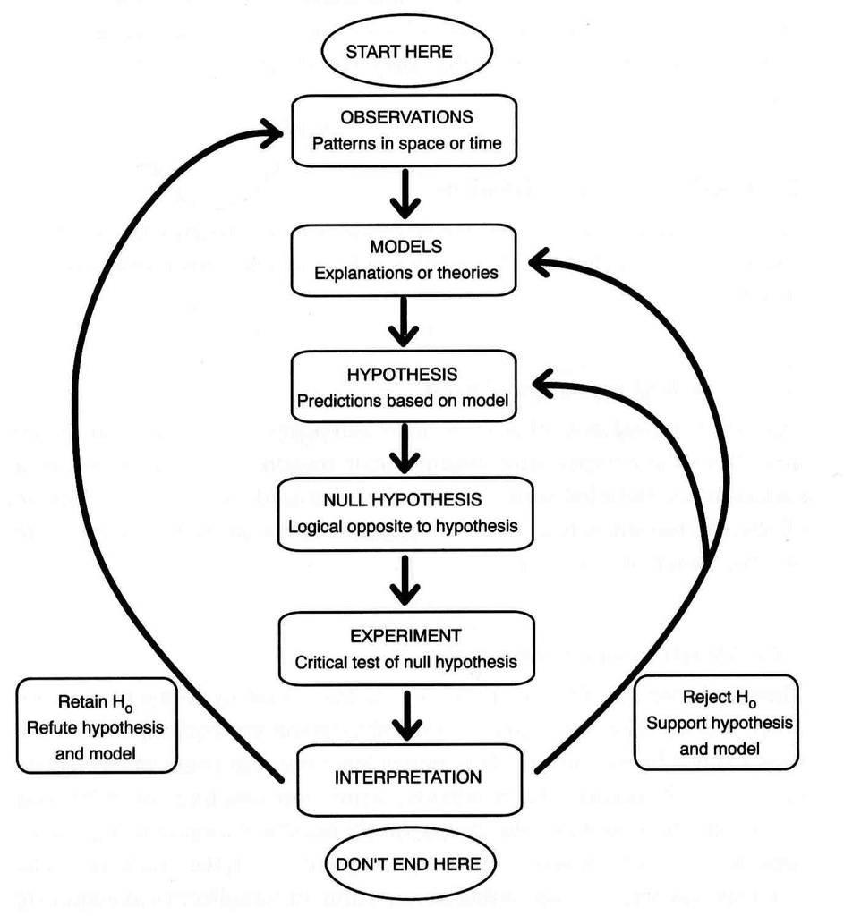

Этапы работы с гипотезами (Underwood, 1997)

Формулировка биологической гипотезы

Численное выражение биологической гипотезы (\(H\))

Формулировка альтернативной гипотезы (\(H_0\) - нулевой гипотезы)

Тестирование нулевой гипотезы

Если \(H_0\) ложна, то признаем, что верна \(H\) и, следовательно, биологическую гипотезу можно рассматривать как истинное утверждение

Если \(H_0\) истинна, то…

## ANOSIM: Analysis Of Similarity

## Пример: Динамика сообществ мидиевых банок

Существуют ли различия в сообществах мидиевых банок, сформированных старыми и молодыми мидиями (Khaitov, 2013)?

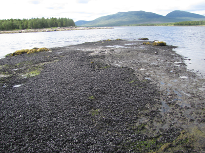

```r
com <- read.csv("data/mussel_beds.csv", sep=';', header = T)

com$Mussel_size <- factor(com$Mussel_size)

ascam <- read.csv("data/ASCAM.csv", sep=';', header = T)
```

`com` — усредненные данные по обилию 12 видов для 3 мидиевых банок (Vor2, Vor4, Vor5).  
`ascam` — (averaged size class abundance matrix) средние плотности поселения мидий разных размеров (6] размерных классов)

## Задание

- Постройте ординацию всех описаний датасета `com` (прологарифмированные данные) в осях nMDS на основе матрицы Брея-Куртиса
- Раскрасьте разными цветами точки, относящиеся к двум разным группам: “Large-dominated” и “Small-dominated”

## Решение

```r
library(vegan)
library(ggplot2)

log_com <- log(com[,-c(1:3)] + 1)

ord_log_com <- metaMDS(log_com, distance = "bray", k=2, autotransform = F, trace = 0)
MDS <- data.frame(ord_log_com$points)
```

## Решение

Обратите внимание, здесь есть две группы расстояний между точками

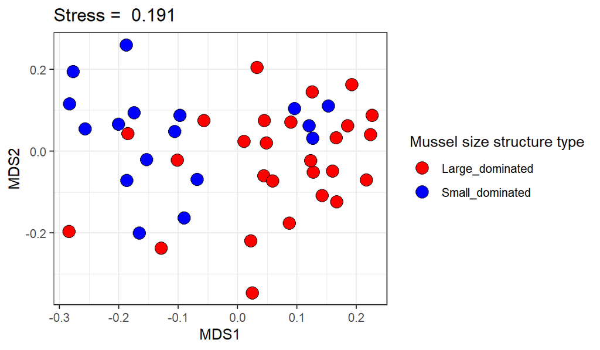

```r
ggplot(MDS, aes(x = MDS1, y = MDS2, fill = com$Mussel_size)) +
  geom_point(shape = 21, size = 4) +
  scale_fill_manual(values = c("red", "blue")) +
  labs(fill = "Mussel size structure type") + ggtitle(paste("Stress = ", round(ord_log_com$stress, 3), sep = " "))
```

## Расстояния между объектами

### 1. Внутригрупповые расстояния

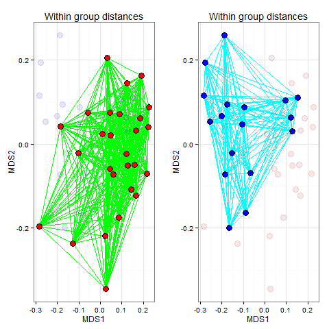

Within group distance

### 2. Межгрупповые расстояния

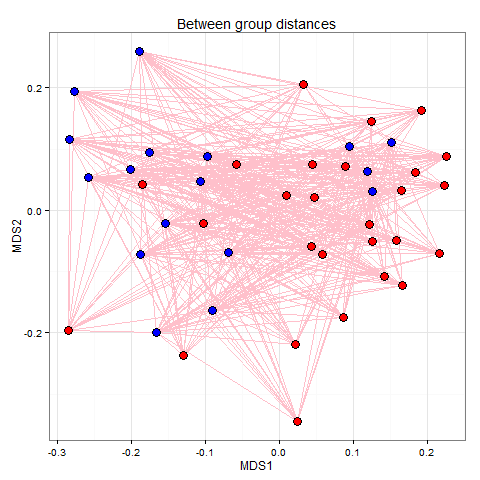

between group distance

## Ранги расстояний

Для работы удобно (но не обязательно!) перейти от исходных расстояний между объектами, к их рангам.

Обозначим внутригрупповые расстояния (ранги), как \(r_w\), а межгрупповые, как \(r_b\).

Вычислим

- средние значения внутригрупповых рангов расстояний \(R_w\)
- средние значения межгрупповых рангов расстояний \(R_b\)

## R - статистика

На основе полученных значений можно построить статистику (Clarke, 1988, 1993)

\[R_{global} = \frac{R_b-R_w}{n(n-1)/4}\]

Эта статистика распределена в интервале -1 < \(R_{global}\) < 1

\(R_{global}\) - оценивает степень разделенности групп в пространстве признаков.

\(R_{global} > 0\) – как минимум есть тенденция к разделению групп

\(R_{global} \rightarrow 1\) – группы разделяются хорошо

\(R_{global} \leq 0\) – нет разделения на группы

## ANOSIM вручную

## Ранги расстояний в пространстве признаков

**Задание:**

1. Вычислите матрицу коэффициентов Брея-Куртиса на основе матрицы `log_com`
2. Разверните полученную матрицу в вектор.
3. На основе полученного вектора создайте вектор, содержащий ранги расстояний.

## Решение

```r
dist_com <- vegdist(log_com, method = "bray")

rank_dist_com <- rank(dist_com)
```

## Внутри- и межгрупповые расстояния

**Задание:**

1. Создайте треугольную матрицу `dummy_dist`, той же размерности, что и матрица `dist_com`, в которой `0` будет с стоять в тех ячейках, которые соответствуют межгрупповым расстояниями, а `1` – внутригрупповым.

## Решение

```r
dummy_dist <- dist(as.numeric(factor(com$Mussel_size)))

dummy_dist <- ifelse(dummy_dist == 0, 0, 1)
```

## R-статистка

**Задание:**

1. Вычислите средние значения рангов внутри- и межгрупповых расстояний
2. Вычислите R-статистику

## Решение

```r
dists <- data.frame(rank_dist = rank_dist_com, dummy = as.vector(dummy_dist))

library(dplyr)

mean_dists <- dists %>% group_by(dummy) %>% summarize(rank_mean = mean(rank_dist))

n <- nrow(log_com)

R_glob <- (mean_dists$rank_mean[2] - mean_dists$rank_mean[1])/(n * (n - 1)/4)
```

> Вопрос: Каков дальнейший ход процедуры `ANOSIM`?

## Пермутации

**Задание:**

1. Напишите пользовательскую функцию (пусть она будет называться `R_perm`), которая пермутировала бы принадлежность каждого объекта к той или иной группе и вычисляла бы значение R-статистики для новой комбинации.
2. Используя функцию `for()` вычислите 10000 значений R-статистики и запишите их в вектор.

Hint. Весь код для пользовательской функции почти такой же, как написали ранее.

## Решение

```r
# функция. Весь код почти такой же, как написали ранее.
R_perm <- function(comm, group){
  require(vegan)
  dist_com <- vegdist(comm)
  rank_dist_com <- rank(dist_com)
  dummy_dist <- dist(sample(as.numeric(group))) #Перемешиваем группы
  dummy_dist <- ifelse(dummy_dist == 0, 0, 1)
  dists <- data.frame(rank = rank_dist_com, dummy = as.vector(dummy_dist))
  require(dplyr)
  mean_dists <- dists %>% group_by(dummy) %>% summarize(rank_type = mean(rank))
  n <- nrow(log_com)
  R_p <- (mean_dists$rank_type[2] - mean_dists$rank_type[1])/(n * (n - 1)/4)
  R_p
}


R_perms <-  rep(NA, 10000)

for(i in 1:9999) R_perms[i] <- R_perm(comm = log_com, group = com$Mussel_size)
```

Вопрос: Что надо добавить в вектор `R_perms`?

## Распределение пермутационных оценок R-статистики

**Задание:**

1. Постройте частотную гистограмму, характеризующую распределение пермутационных оценок.
2. Нанесите на нее полученное значение \(R_{global}\).
3. Вычислите уровень значимости.

## Решение

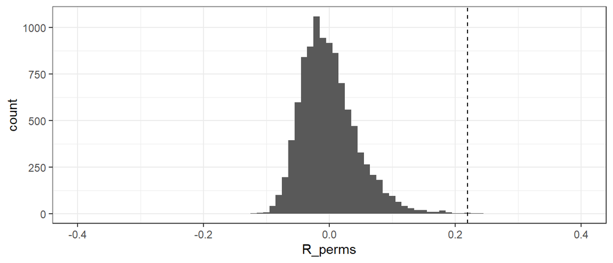

```r
R_perms[10000] <- R_glob

Pl_manual <- ggplot(data.frame(R_perms), aes(x = R_perms)) +
  geom_histogram(binwidth = 0.01) +
  geom_vline(xintercept = R_glob, linetype = 2) + xlim(-0.4, 0.4)

Pl_manual
```

## Решение

Вычисляем уровень значимости

```r
p_level <- mean(R_perms >= R_glob)
p_level
```

```
## [1] 0.0009
```

## Процедура ANOSIM в пакете `vegan`

## Специализированная функция `anosim()`

```r
com_anosim <- anosim(log_com,
           grouping = com$Mussel_size,
           permutations = 9999,
           distance = "bray")
```

## Задание

Изучите структуру объекта `com_anosim` и постройте частотное распределение значений \(R_{global}\), полученных при каждом акте пермутации

## Решение

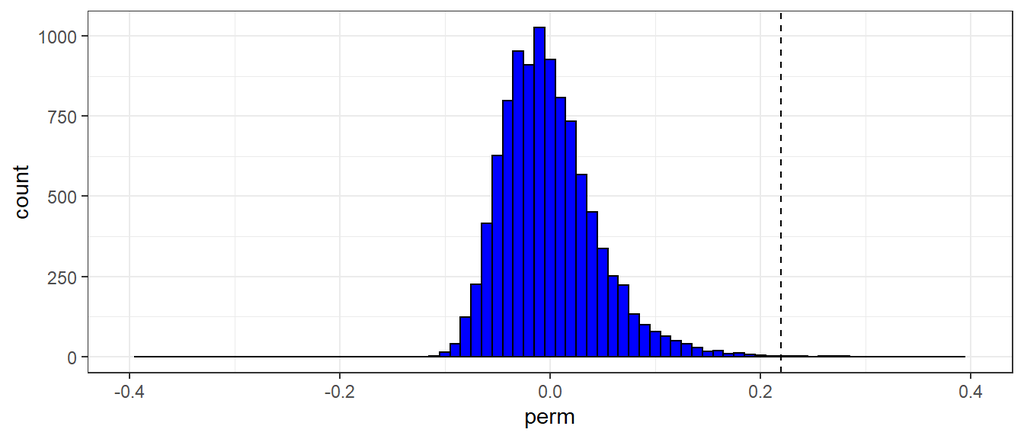

```r
anosim_perm <- data.frame(perm = com_anosim$perm)

anosim_perm[(com_anosim$permutations + 1), 1] <- com_anosim$statistic

Pl_prof <- ggplot(anosim_perm, aes(x = perm)) +
  geom_histogram(binwidth = 0.01, color = "black", fill = "blue") +
  geom_vline(xintercept = com_anosim$statistic, linetype = 2)  + xlim(-0.4, 0.4)
Pl_prof
```

## Сравним результаты ручной и автоматической обработки

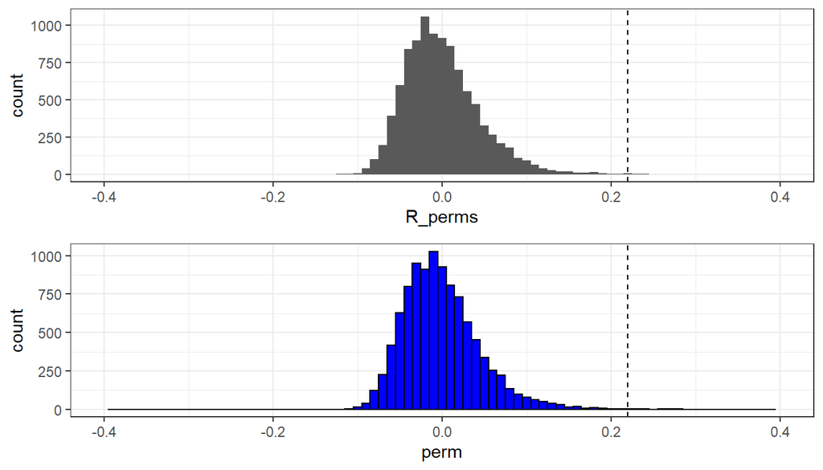

## Результаты процедуры ANOSIM

```r
summary(com_anosim)
```

```
##
## Call:
## anosim(x = log_com, grouping = com$Mussel_size, permutations = 9999,      distance = "bray")
## Dissimilarity: bray
##
## ANOSIM statistic R: 0.219
##       Significance: 0.001
##
## Permutation: free
## Number of permutations: 9999
##
## Upper quantiles of permutations (null model):
##    90%    95%  97.5%    99%
## 0.0567 0.0791 0.1062 0.1363
##
## Dissimilarity ranks between and within classes:
##                 0% 25% 50% 75% 100%   N
## Between          1 302 549 766  946 459
## Large_dominated  4 193 360 645  945 351
## Small_dominated  3 275 478 683  938 136
```

## Ограничения (Assumptions) для применения ANOSIM

### 1) Внутригрупповые расстояния (ранги) для разных групп должны иметь приблизительно равные медианы и пределы варьирования.

Для проверки этого допущения надо сравнить распределения внутригрупповых и межгрупповых расстояний (рангов)

Распределение расстояний имеет следующий вид

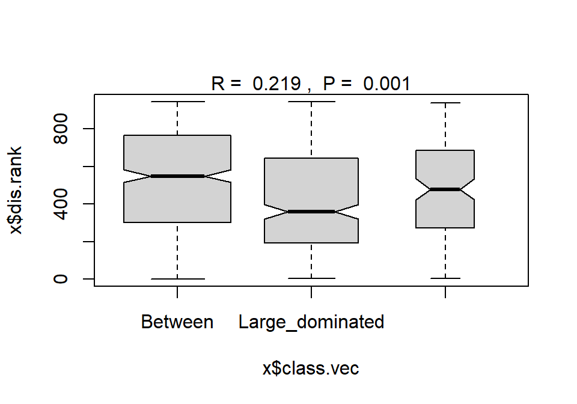

```r
plot(com_anosim)
```

## ANOSIM позволяет сравнивать одновременно и несколько групп

НО! Есть одно очень важное ограничение:

### 2) Попарные сравненения групп можно осуществлять только если было показано, что \(R_{global}\) статистически значимо.

Если это условие выполнено, то можно проводить попарные сравнения

### Пример

Пусть у нас есть три группы объектов: A, B, C.  
Можно вычислить \(R_{A vs B}\), \(R_{A vs C}\), \(R_{B vs C}\).

Но при больших объемах выборки даже незначительные различия будут достоверны. Важно обращать внимание не только на оценку статистической значимости, но и на значения R!

**Важно!** При множественных сравнениях придется вводить поправку Бонферрони.

NB! Для сравнения нескольких групп многомерных объектов, есть более мощное средство - **PERMANOVA**

## Задание

- Постройте ординацию в осях nMDS, раскрасив точки в разные цвета в зависимости от номера мидиевой банки
- Проверьте гипотезу о различиях в структуре сообществ на разных банках
- Проверьте условия применимости ANOSIM
- Проведите попарное сравнение всех банок

## Решение

### График ординации

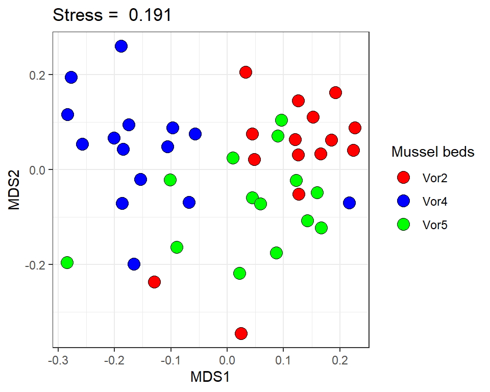

```r
ggplot(MDS, aes(x = MDS1, y = MDS2, fill = com$Bank)) +
  geom_point(shape = 21, size = 4) +
  scale_fill_manual(values = c("red", "blue", "green")) +
  labs(fill = "Mussel beds") + ggtitle(paste("Stress = ", round(ord_log_com$stress, 3), sep = " "))
```

## Решение

### Проверка гипотезы о различиях в структуре сообществ на разных банках

```r
bed_anosim <- anosim(log_com, grouping = com$Bank,permutations = 999, distance = "bray")
bed_anosim
```

```
##
## Call:
## anosim(x = log_com, grouping = com$Bank, permutations = 999,      distance = "bray")
## Dissimilarity: bray
##
## ANOSIM statistic R: 0.44
##       Significance: 0.001
##
## Permutation: free
## Number of permutations: 999
```

## Решение

### Условия применимости

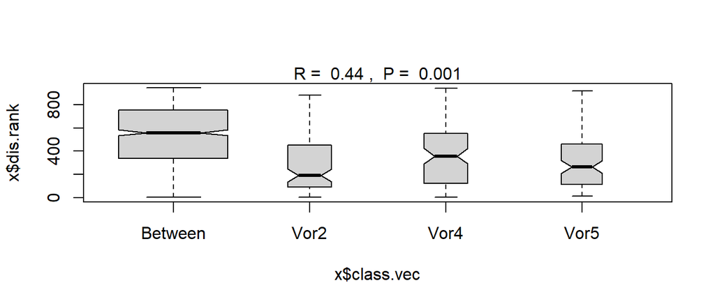

```r
plot(bed_anosim)
```

## Решение

### Попарные сравнения Vor2 vs Vor4

```r
# Vor2 vs Vor4
anosim(log_com [com$Bank %in% c("Vor2", "Vor4"),],
    grouping = com$Bank[com$Bank %in% c("Vor2", "Vor4")])
```

```
##
## Call:
## anosim(x = log_com[com$Bank %in% c("Vor2", "Vor4"), ], grouping = com$Bank[com$Bank %in%      c("Vor2", "Vor4")])
## Dissimilarity: bray
##
## ANOSIM statistic R: 0.588
##       Significance: 0.001
##
## Permutation: free
## Number of permutations: 999
```

## Попарные сравнения Vor2 vs Vor5

```r
# Vor2 vs Vor5
anosim(log_com[com$Bank %in% c("Vor2", "Vor5"),], grouping = com$Bank[com$Bank %in% c("Vor2", "Vor5")])
```

```
##
## Call:
## anosim(x = log_com[com$Bank %in% c("Vor2", "Vor5"), ], grouping = com$Bank[com$Bank %in%      c("Vor2", "Vor5")])
## Dissimilarity: bray
##
## ANOSIM statistic R: 0.309
##       Significance: 0.001
##
## Permutation: free
## Number of permutations: 999
```

## Попарные сравнения Vor4 vs Vor5

```r
# Vor4 vs Vor5
anosim(log_com [com$Bank %in% c("Vor4", "Vor5"),], grouping = com$Bank[com$Bank %in% c("Vor4", "Vor5")])
```

```
##
## Call:
## anosim(x = log_com[com$Bank %in% c("Vor4", "Vor5"), ], grouping = com$Bank[com$Bank %in%      c("Vor4", "Vor5")])
## Dissimilarity: bray
##
## ANOSIM statistic R: 0.426
##       Significance: 0.001
##
## Permutation: free
## Number of permutations: 999
```

## Проблема малых выборок

Мощность ANOSIM невелика.

При малых выборках пермутационная оценка уровня значимости может не выявить достоверных различий, даже при очень высоком значении R.

## SIMPER: Similarity Percentages

## Какие признаки зависимой матрицы вносят наибольший вклад в формирование различий между группами?

```r
log_com_simper <- simper(log_com, group = com$Mussel_size, permutations = 999)
summary (log_com_simper)
```

```
##
## Contrast: Large_dominated_Small_dominated
##
##                        average      sd ratio   ava   avb cumsum     p
## Polydora_quadrilobata  0.04185 0.02941  1.42 0.862 2.425  0.177 0.003 **
## Hydrobia_ulvae         0.02598 0.01812  1.43 3.259 2.826  0.287 0.903
## Skeneopsis_planorbis   0.02343 0.01722  1.36 0.380 1.282  0.387 0.001 ***
## Fabricia_sabella       0.02234 0.01799  1.24 0.921 1.312  0.481 0.348
## Cricotopus_vitripennis 0.02097 0.01512  1.39 1.687 2.221  0.570 0.130
## Onoba_aculeus          0.01879 0.01319  1.42 1.066 1.575  0.650 0.026 *
## Nemertini              0.01718 0.01417  1.21 2.159 2.511  0.722 0.145
## Macoma_balthica        0.01544 0.01299  1.19 2.605 2.678  0.788 0.654
## Littorina_saxatilis    0.01542 0.01003  1.54 2.045 1.689  0.853 0.005 **
## Filamentous_algae      0.01505 0.01145  1.31 0.828 0.629  0.917 0.958
## Gammarus_sp.           0.01145 0.00892  1.28 1.766 1.916  0.965 0.889
## Tubificoides_benedeni  0.00821 0.00613  1.34 4.859 4.755  1.000 0.924
## ---
## Signif. codes:  0 '***' 0.001 '**' 0.01 '*' 0.05 '.' 0.1 ' ' 1
## Permutation: free
## Number of permutations: 999
```

## Оценка вклада в формирование различий

\[Contr_i = \frac{|{y_{i,j}-y_{i,k}}|}{\sum{(y_{i,j}-y_{i,k})}}\]

\(y_{i,j}-y_{i,k}\) - разность значений \(i\)-той переменной (вида) в объектах (пробах) \(j\) и \(k\)

Величины \(Contr_i\) далее усредняются для всех межгрупповых пар \(average\)

\(sd\) - среднеквадратичное отклонение

Отношение \(average/sd\) характеризует дискриминирующую силу переменной

## Задание

Выявите виды, отвечающие за различия в сообществах разных банок

## Решение

```r
summary(simper(log_com, group = com$Bank, permutations = 999 ))
```

```
##
## Contrast: Vor2_Vor4
##
##                        average      sd ratio    ava   avb cumsum     p
## Polydora_quadrilobata  0.04661 0.02795  1.67 0.6680 2.804  0.180 0.002 **
## Hydrobia_ulvae         0.03246 0.01559  2.08 3.6840 2.456  0.305 0.004 **
## Skeneopsis_planorbis   0.02820 0.01816  1.55 0.0486 1.460  0.414 0.001 ***
## Fabricia_sabella       0.02229 0.01699  1.31 1.5530 1.095  0.500 0.471
## Nemertini              0.02103 0.01389  1.51 1.9237 2.531  0.582 0.001 ***
## Filamentous_algae      0.01947 0.01314  1.48 1.1917 0.419  0.657 0.004 **
## Onoba_aculeus          0.01845 0.01375  1.34 0.8647 1.416  0.728 0.214
## Littorina_saxatilis    0.01741 0.01013  1.72 2.1832 1.361  0.795 0.001 ***
## Cricotopus_vitripennis 0.01703 0.01182  1.44 2.0702 2.343  0.861 0.986
## Macoma_balthica        0.01426 0.01224  1.16 2.7410 2.767  0.916 0.831
## Gammarus_sp.           0.01218 0.00936  1.30 1.8253 1.994  0.963 0.389
## Tubificoides_benedeni  0.00949 0.00664  1.43 5.0329 4.712  1.000 0.066 .
##
## Contrast: Vor2_Vor5
##
##                        average      sd ratio    ava   avb cumsum     p
## Hydrobia_ulvae          0.0289 0.02376 1.216 3.6840 3.139  0.133 0.182
## Fabricia_sabella        0.0275 0.01847 1.491 1.5530 0.531  0.260 0.001 ***
## Polydora_quadrilobata   0.0220 0.02301 0.955 0.6680 0.889  0.361 1.000
## Cricotopus_vitripennis  0.0217 0.01407 1.541 2.0702 1.222  0.461 0.190
## Onoba_aculeus           0.0192 0.01373 1.396 0.8647 1.525  0.550 0.112
## Filamentous_algae       0.0180 0.01220 1.479 1.1917 0.634  0.633 0.026 *
## Macoma_balthica         0.0168 0.01317 1.274 2.7410 2.375  0.710 0.288
## Nemertini               0.0165 0.01208 1.368 1.9237 2.439  0.786 0.565
## Skeneopsis_planorbis    0.0138 0.01094 1.261 0.0486 0.673  0.850 0.995
## Gammarus_sp.            0.0123 0.00893 1.374 1.8253 1.641  0.907 0.335
## Littorina_saxatilis     0.0102 0.00712 1.430 2.1832 2.196  0.953 1.000
## Tubificoides_benedeni   0.0101 0.00690 1.461 5.0329 4.703  1.000 0.014 *
##
## Contrast: Vor4_Vor5
##
##                        average      sd ratio   ava   avb cumsum     p
## Polydora_quadrilobata  0.04702 0.02844  1.65 2.804 0.889  0.196 0.001 ***
## Cricotopus_vitripennis 0.02797 0.01679  1.67 2.343 1.222  0.313 0.001 ***
## Hydrobia_ulvae         0.02465 0.01588  1.55 2.456 3.139  0.416 0.835
## Skeneopsis_planorbis   0.02372 0.01545  1.54 1.460 0.673  0.514 0.002 **
## Fabricia_sabella       0.02009 0.01698  1.18 1.095 0.531  0.598 0.856
## Littorina_saxatilis    0.01874 0.01087  1.72 1.361 2.196  0.676 0.001 ***
## Onoba_aculeus          0.01641 0.01182  1.39 1.416 1.525  0.745 0.807
## Macoma_balthica        0.01628 0.01375  1.18 2.767 2.375  0.813 0.395
## Nemertini              0.01431 0.01378  1.04 2.531 2.439  0.872 0.893
## Filamentous_algae      0.01229 0.00855  1.44 0.419 0.634  0.924 0.998
## Gammarus_sp.           0.01154 0.00931  1.24 1.994 1.641  0.972 0.624
## Tubificoides_benedeni  0.00676 0.00494  1.37 4.712 4.703  1.000 0.994
## ---
## Signif. codes:  0 '***' 0.001 '**' 0.01 '*' 0.05 '.' 0.1 ' ' 1
## Permutation: free
## Number of permutations: 999
```

## Summary

- ANOSIM — простейший вариант сравнения нескольких групп объектов, охарактеризованных по многим признакам.
- С помощью процедуры SIMPER можно оценить вклад отдельных переменных в формирование различий между группами.

## Что почитать

- Clarke, K. R., Gorley R. N. (2006) PRIMER v6: User Manual/Tutorial. PRIMER-E, Plymouth.
- Legendre P., Legendre L. (2012) Numerical ecology. Second english edition. Elsevier, Amsterdam.